# Flight Delays Data Exploration

## by Jaime Auger

## Investigation Overview

In this research, I wanted to take a look at the KPIs related to flights in the United States from january 2004 to december 2020, including delays, cancellations and reasons for delays.

## Dataset Overview

There are 283,129 instances of delayed flight statistics in the dataset. The main features of interest are the quantity & durations of flights delayed, and also the distribution of types of delays along months and years.

## Distribution for the durations of delays per delayed flight

The variable plotted is the duration of delay/number of flights delayed for more than 15 minutes. The new variable has a normal distribution with a mean around 50 minutes of delay per each flight delayed.

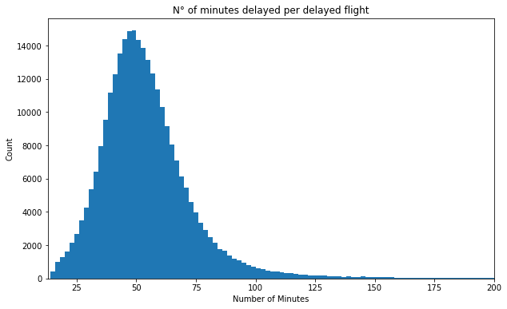

## Distribution for the porcentage of delayed flights from the total arrived flights

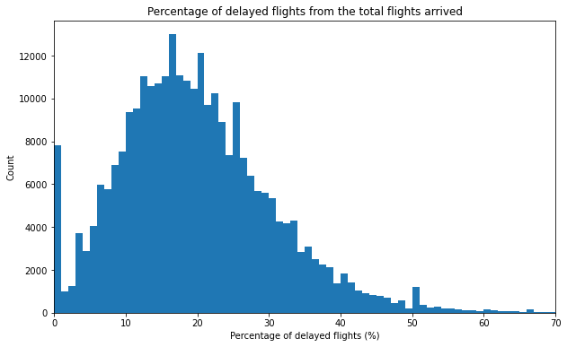

## Distribution for the porcentage of cancelled flights

Thanks to the logarithmic scale transformation, we can see that the porcentage of cancelled flights behaves like a bimodal normal distribution with two peaks at 1.8% and 3.5% of cancellations.

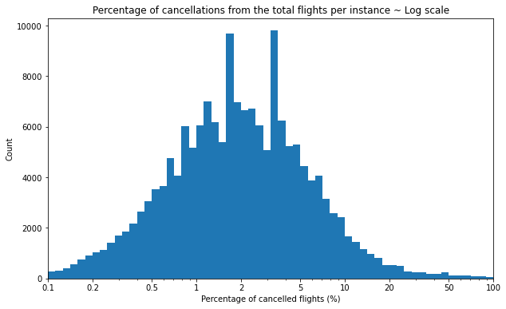

## Mean Number of delayed flights & the mean duration of delayed flights by type of delay

The late_aircraft is the type of delay that occurs more times and whose durations are longer than the rest on average. On the other hand, security and weather remain as the reasons for the least occurrence and as the shortest delays. Something interesting happens with the nas and carrier types because on average a greater number of flights are delayed for nas reasons but the durations of delays per carrier are longer on average.

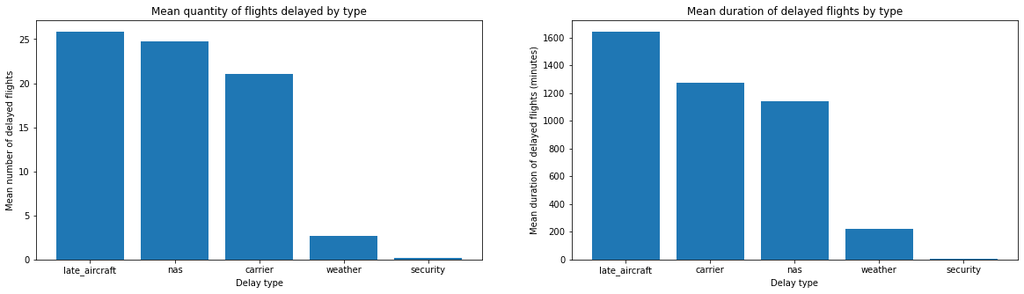

## Distribution for the delay-types for delayed flights by year

The annual graph shows an abrupt rise in delays with respect to carrier (airline) and nas (National Aviation Services) types of delay, a direct consequence of the pandemic as more exhaustive sanitation protocols were added. This is justified with a lower number of delayed flights by late_aircraft since due to the pandemic the number of flights has been abysmally reduced and there is not so much demand so there are more unoccupied planes. You can also see a steady increase in the number of delays caused by late_aircraft until 2019.

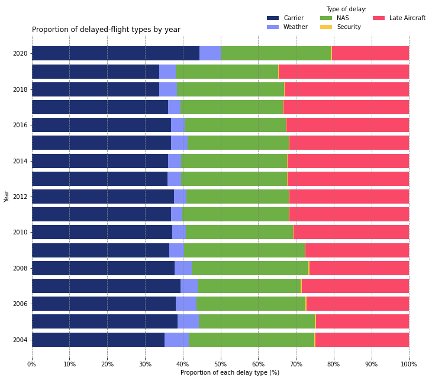

## Distribution of delay-types for delayed flights by month

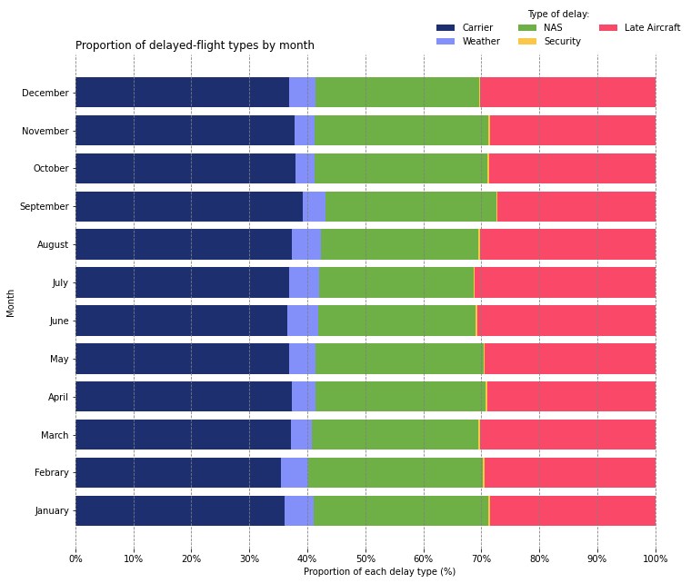

## Behaviour of the porcentage of flights delayed by month and type of delay

When viewing the visualization, a marked seasonality can be clearly appreciated the quantity of flights delayed by carrier, late_aircraft, nas and, with less strength, weather. The security cause of delay has the same seasonality but because of its fewer occurrence its not appreciable.

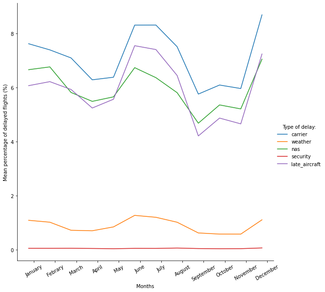